# Gapminder Analysis

Maureen Rocas

Wednesday, February 04, 2015

This is a study of the Gapminder dataset for Unemployment Rate for Aged 25-54.

```
## [1] "C:/Users/mrocas/Documents/docs/tutorials/udacity/Data Analysis with R/Lesson 3"
```

Load Gapminder data

```r
gapminder <- read.csv('indicator_t 25-54 unemploy.csv')
names(gapminder)
```

```
##  [1] "Total.25.54.unemployment...." "X1981"
##  [3] "X1982"                        "X1983"
##  [5] "X1984"                        "X1985"
##  [7] "X1986"                        "X1987"
##  [9] "X1988"                        "X1989"
## [11] "X1990"                        "X1991"
## [13] "X1992"                        "X1993"
## [15] "X1994"                        "X1995"
## [17] "X1996"                        "X1997"
## [19] "X1998"                        "X1999"
## [21] "X2000"                        "X2001"
## [23] "X2002"                        "X2003"
## [25] "X2004"                        "X2005"
## [27] "X"
```

```r
dim(gapminder)
```

```
## [1] 30 27
```

Let’s clean up data by: - renaming ’Total.25.54.unemployment…." column to Country - removing the last column “X” as this contains NA value - removing the last row as this contain NULL

```r
gapminder$x
```

```r
gapminder$Total.25.54.unemployment....
```

```
##  [1] Australia        Canada           Czech Rep.       Estonia
##  [5] Finland          France           Germany          Hong Kong, China
##  [9] Ireland          Japan            Korea, Rep.      Latvia
## [13] Lithuania        Netherlands      New Zealand      Norway
## [17] Philippines      Poland           Portugal         Romania
## [21] Singapore        Slovak Republic  Slovenia         Spain
## [25] Sweden           Switzerland      Turkey           United Kingdom
## [29] United States
## 30 Levels:  Australia Canada Czech Rep. Estonia Finland France ... United States
```

```r
# rename column
gapminder <- rename(gapminder, c(Total.25.54.unemployment....="Country"))

#remove last column
gapminder <- subset(gapminder,select=-X)

#remove last row
gapminder <- gapminder[1:(nrow(gapminder)-1),]


#Add country_id
gapminder$CountryId <- c(1:29)

dim(gapminder)
```

```
## [1] 29 27
```

Plot histogram

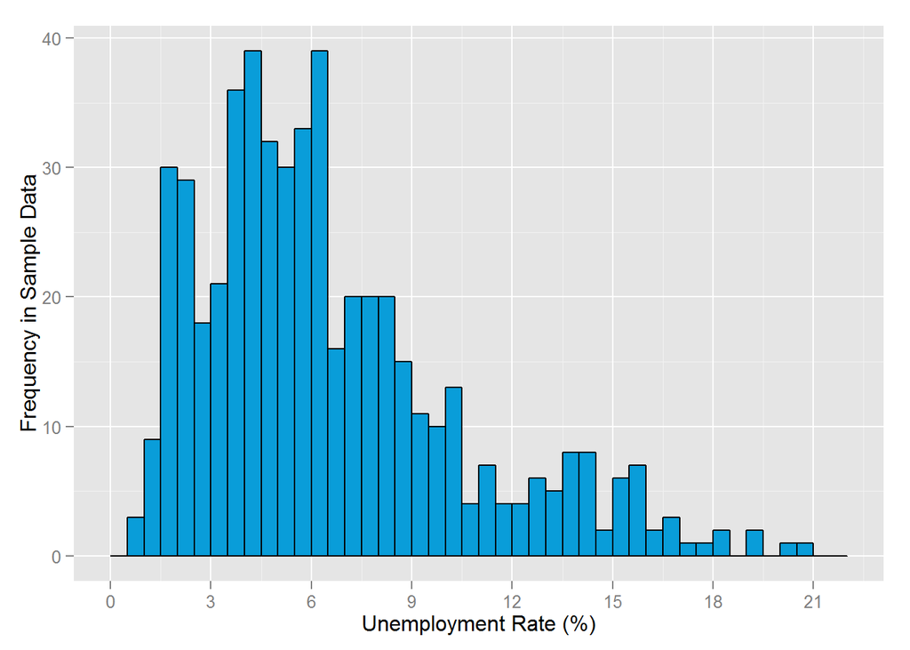

```r
#melt data by country
gapminder1 <- melt(gapminder[,1:27], id=c("Country", "CountryId"))

#Add a new Date Column, convert Year(variable) to a date dataype
gapminder1 <- transform(gapminder1, Date=rep(as.Date(variable,"X%Y")), nrow(gapminder1))

#remove rows with NA values
gapminder1NoNA <- subset(gapminder1, !is.na(value))

#Histogram
qplot(data=gapminder1NoNA,x=value, binwidth=0.50,
      xlab="Unemployment Rate (%)",
      ylab="Frequency in Sample Data",
      color=I("black"), fill=I("#099DD9")) +
      scale_x_continuous(lim=c(0,22), breaks=seq(0,22,3))
```

The histogram shows that the concentration of data is around 3.5 to 6.5 unemployment rate. Let’s see the total number of observations per country.

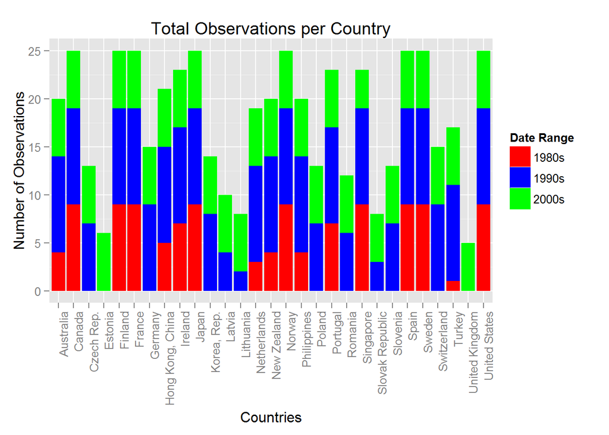

```r
# Total Observations per Country
qplot(data=gapminder1NoNA,x=Country,
      xlab="Countries",
      main="Total Observations per Country",
      fill=ifelse(as.numeric(format(Date, "%Y")) < 1990, "1980s",ifelse(as.numeric(format(Date, "%Y")) < 2000, "1990s", "2000s")),
      geom="bar") +
  ylab("Number of Observations") +
  scale_fill_manual(name="Date Range", values=c("1980s"="red","1990s"="blue","2000s"="green")) +
  theme(axis.text.x = element_text(angle = 90, hjust = 1))
```

Here is a boxplot, showing the median and quantile values for each Country

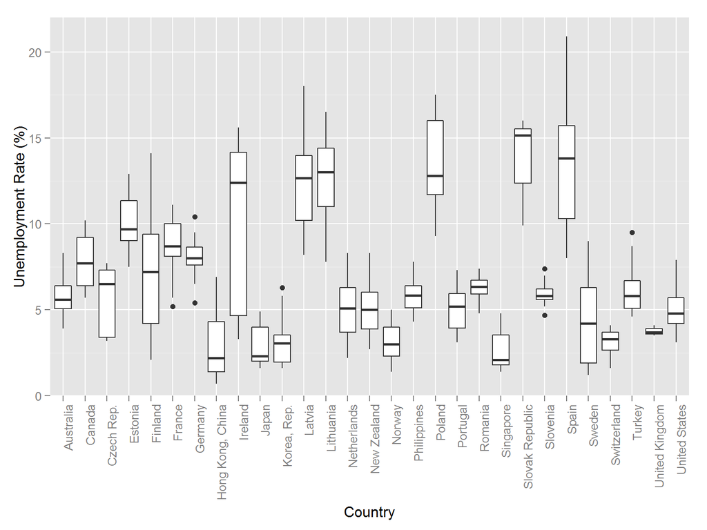

```r
qplot(data=gapminder1NoNA, x=Country, y=value,
      geom="boxplot") +
  ylab("Unemployment Rate (%)") +
  coord_cartesian(ylim=c(0,22))  +
  theme(axis.text.x = element_text(angle = 90, hjust = 1))
```

```r
#Overall summary statistics
by(gapminder1NoNA$value, gapminder1NoNA$Country, summary)
```

```
## gapminder1NoNA$Country:
## NULL
## --------------------------------------------------------
## gapminder1NoNA$Country: Australia
##    Min. 1st Qu.  Median    Mean 3rd Qu.    Max.
##   3.900   5.075   5.600   5.820   6.400   8.300
## --------------------------------------------------------
## gapminder1NoNA$Country: Canada
##    Min. 1st Qu.  Median    Mean 3rd Qu.    Max.
##   5.700   6.400   7.700   7.764   9.200  10.200
## --------------------------------------------------------
## gapminder1NoNA$Country: Czech Rep.
##    Min. 1st Qu.  Median    Mean 3rd Qu.    Max.
##   3.200   3.400   6.500   5.654   7.300   7.700
## --------------------------------------------------------
## gapminder1NoNA$Country: Estonia
##    Min. 1st Qu.  Median    Mean 3rd Qu.    Max.
##   7.500   9.025   9.700  10.080  11.350  12.900
## --------------------------------------------------------
## gapminder1NoNA$Country: Finland
##    Min. 1st Qu.  Median    Mean 3rd Qu.    Max.
##   2.100   4.200   7.200   7.084   9.400  14.100
## --------------------------------------------------------
## gapminder1NoNA$Country: France
##    Min. 1st Qu.  Median    Mean 3rd Qu.    Max.
##   5.200   8.100   8.700   8.696  10.000  11.100
## --------------------------------------------------------
## gapminder1NoNA$Country: Germany
##    Min. 1st Qu.  Median    Mean 3rd Qu.    Max.
##    5.40    7.60    8.00    8.12    8.65   10.40
## --------------------------------------------------------
## gapminder1NoNA$Country: Hong Kong, China
##    Min. 1st Qu.  Median    Mean 3rd Qu.    Max.
##   0.700   1.400   2.200   2.881   4.300   6.900
## --------------------------------------------------------
## gapminder1NoNA$Country: Ireland
##    Min. 1st Qu.  Median    Mean 3rd Qu.    Max.
##    3.30    4.65   12.40   10.29   14.15   15.60
## --------------------------------------------------------
## gapminder1NoNA$Country: Japan
```

[output cut: 63 more lines]

```
## gapminder1NoNA$Country: Switzerland
##    Min. 1st Qu.  Median    Mean 3rd Qu.    Max.
##    1.60    2.65    3.30    3.10    3.70    4.10
## --------------------------------------------------------
## gapminder1NoNA$Country: Turkey
##    Min. 1st Qu.  Median    Mean 3rd Qu.    Max.
##   4.600   5.100   5.800   6.294   6.700   9.500
## --------------------------------------------------------
## gapminder1NoNA$Country: United Kingdom
##    Min. 1st Qu.  Median    Mean 3rd Qu.    Max.
##    3.50    3.60    3.70    3.76    3.90    4.10
## --------------------------------------------------------
## gapminder1NoNA$Country: United States
##    Min. 1st Qu.  Median    Mean 3rd Qu.    Max.
##   3.100   4.200   4.800   4.968   5.700   7.900
```

Let’s look at the Unemployment Rate per year per Country.

Here we can see the decreasing or increasing unemployment rate per country per year

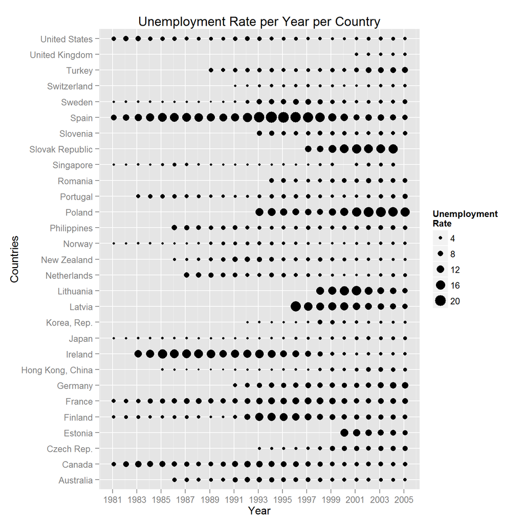

```r
#Unemployment Rate per Date
qplot(x=Date, y=Country,
      data=gapminder1NoNA, binwidth=1,
      xlab="Year",
      size=value,
      geom="point",
      main="Unemployment Rate per Year per Country",
      ylab="Countries") +
  scale_size_continuous(name="Unemployment\nRate", breaks=seq(0,22, 4)) +
  scale_x_date(lim=c(as.Date("1981", "%Y"), as.Date("2005", "%Y")),
                     breaks=date_breaks("2 years"),
                     labels=date_format("%Y"))
```